# Linear Regression

# Overview

- The linear regression model
- $p$-values and confidence intervals
- Model accuracy
- Multiple predictors
- Categorical predictors

For further reading, see [JWHT], pp. 59-87.

# The Linear Regression Model

## Recall: Statistical Learning

- We have a list $X$ of **predictor** variables $X = (X_1, X_2, \ldots, X_p)$.
- We have a continuous **response** variable $Y$ we would like to predict. Our general **model** is:
  $$Y = f(X) + \epsilon$$

In **Linear Regression**, we represent $f(X)$ with a *linear combination* of the predictor variables, plus an intercept $\beta_0$:

$$Y = \beta_0 + \beta_1 X_1 +\beta_2 X_2 + \cdots + \beta_p X_p + \epsilon$$

## Simple Linear Regression

- Model: $Y = \beta_0 + \beta_1X + \epsilon$
- Estimate: $\hat{y} = \hat{\beta}_0 + \hat{\beta}_1 x$
  - $\hat{\beta}_0$ and $\hat{\beta}_1$ are **statistics** (calculated from data), the **regression intercept** and **regresssion slope**.
- Given a set of observations $(x_1,y_1), (x_2,y_2), \ldots, (x_n,y_n)$, we calculate $\hat{\beta}_0$ and $\hat{\beta}_1$ so that the **residual sum of squares** $\text{RSS}$ is minimized:
  $$\begin{align}
  \text{RSS} &= \sum_{i=1}^n (y_i - \hat{y}_i)^2 \\
  &= (y_1 -\hat{\beta}_0 -\hat{\beta}_1x_1)^2 + (y_2 -\hat{\beta}_0
  -\hat{\beta}_1x_2)^2 + \cdots + (y_n -\hat{\beta}_0 -\hat{\beta}_1x_n)^2
  \end{align}$$
- Calculus exercise.

# Inference on the regression coefficients

## Get the Advertising data set

Some of the data sets are not included in the `ISLR2` package, but they [are posted online](https://www.statlearning.com/resources-first-edition).

```r
library(tidyverse)
Advertising <- read_csv("https://www.statlearning.com/s/Advertising.csv")
glimpse(Advertising)
```

```
Rows: 200
Columns: 5
$ ...1      <dbl> 1, 2, 3, 4, 5, 6, 7, 8, 9, 10, 11, 12, 13, 14, 15, 16, 17, 18, 19, 20, 21, 22, 2…
$ TV        <dbl> 230.1, 44.5, 17.2, 151.5, 180.8, 8.7, 57.5, 120.2, 8.6, 199.8, 66.1, 214.7, 23.8…
$ radio     <dbl> 37.8, 39.3, 45.9, 41.3, 10.8, 48.9, 32.8, 19.6, 2.1, 2.6, 5.8, 24.0, 35.1, 7.6, …
$ newspaper <dbl> 69.2, 45.1, 69.3, 58.5, 58.4, 75.0, 23.5, 11.6, 1.0, 21.2, 24.2, 4.0, 65.9, 7.2,…
$ sales     <dbl> 22.1, 10.4, 9.3, 18.5, 12.9, 7.2, 11.8, 13.2, 4.8, 10.6, 8.6, 17.4, 9.2, 9.7, 19…
```

## Simple Linear Regression in R

```r
adMod1 <- lm(sales ~ TV, data = Advertising)
summary(adMod1)
```

```
Call:
lm(formula = sales ~ TV, data = Advertising)

Residuals:
    Min      1Q  Median      3Q     Max
-8.3860 -1.9545 -0.1913  2.0671  7.2124

Coefficients:
            Estimate Std. Error t value Pr(>|t|)
(Intercept) 7.032594   0.457843   15.36   <2e-16 ***
TV          0.047537   0.002691   17.67   <2e-16 ***
---
Signif. codes:  0 '***' 0.001 '**' 0.01 '*' 0.05 '.' 0.1 ' ' 1

Residual standard error: 3.259 on 198 degrees of freedom
Multiple R-squared:  0.6119,    Adjusted R-squared:  0.6099
F-statistic: 312.1 on 1 and 198 DF,  p-value: < 2.2e-16
```

## The prediction equation

```
            Estimate Std. Error t value Pr(>|t|)
(Intercept)   7.0326    0.45784    15.4 1.41e-35
TV            0.0475    0.00269    17.7 1.47e-42
```

- The `Estimate` column gives the least-squares estimates for the regression coefficients $\beta_i$.
- In our case, $\hat{\beta}_0 \approx 7.03$ and $\hat{\beta}_1 \approx 0.048$.
- The **prediction equation** is $\hat{y} = 7.03 + 0.048 x$.

## The Standard Error of a Statistic

```
            Estimate Std. Error t value Pr(>|t|)
(Intercept)   7.0326    0.45784    15.4 1.41e-35
TV            0.0475    0.00269    17.7 1.47e-42
```

- Statistics (like $\hat{\beta}_0$ and $\hat{\beta}_1$) can be regarded as *random variables*, because the data comes from a random sample.
- These random variables have variances (and standard deviations).
- The standard deviation of the random variable is the **standard error** of the statistic.

$$\text{SE}(\hat{\beta}_0)^2 = \sigma^2\left[\frac{1}{n} +
\frac{\bar{x}^2}{\sum_{i=1}^n (x_i - \bar{x})^2}\right], \quad
\text{SE}(\hat{\beta}_1)^2 = \frac{\sigma^2}{\sum_{i=1}^n (x_i -
\bar{x})^2 }$$

Here $\sigma^2 = \text{Var}(\epsilon)$, which is generally unknown in most applications.

## The $t$-statistic

```
            Estimate Std. Error t value Pr(>|t|)
(Intercept)   7.0326    0.45784    15.4 1.41e-35
TV            0.0475    0.00269    17.7 1.47e-42
```

- In practice, $\sigma$ must be estimated from data as $\text{RSE} = \sqrt{\text{RSS}/(n-p-1)}$, where $p$ is the number of predictors.
- In this case, the coefficients are distributed according to the $t$-distribution.
- The $t$-value is $(\text{estimate} - 0)/\text{SE}$.
- The two-tail area `Pr(>|t|)` is the proportion of the $t$-distribution that is more extreme than the $t$-value.

## P-values

```
            Estimate Std. Error t value Pr(>|t|)
(Intercept)   7.0326    0.45784    15.4 1.41e-35
TV            0.0475    0.00269    17.7 1.47e-42
```

- The two-tail area `Pr(>|t|)` is called a **p-value**.
- It is the probability, *assuming that $\beta_i = 0$*, of observing a sample with a $\hat{\beta}_i$ as extreme as the one you observed.
  - If this probability is small, we have evidence that $\beta_i \neq 0$.

Formally, a small p-value is evidence against the **null hypothesis** $H_0$ in favor of the **alternative hypothesis** $H_A$.

$$\begin{align}
H_0: & \;\; \beta_i = 0 \\
H_A: & \;\; \beta_i \neq 0 \\
\end{align}$$

## Confidence Intervals

```
            Estimate Std. Error t value Pr(>|t|)
(Intercept)   7.0326    0.45784    15.4 1.41e-35
TV            0.0475    0.00269    17.7 1.47e-42
```

- Like the normal distribution, approximately 95% of the $t$-distribution lies within 2 standard deviations of the mean.
- So a quick **95% confidence interval** for $\beta_i$ is $\hat{\beta}_i \pm 2 \cdot \text{SE}(\hat{\beta}_i)$.
  - Technically, “2” should be replaced by the appropriate quantile of the $t$-distribution with $n-2$ degrees of freedom.
- $0.0475 \pm 2 \cdot 0.00269 \approx (0.042, 0.053)$
- “We are 95% confident that the true value of $\beta_1$ is between 0.042 and 0.053.”
  - This interval was constructed via a process that will capture the true $\beta_1$ value 95% of the time.

## Percentiles and quantiles of the $t$-distribution

```
              Estimate  Std. Error  t value    Pr(>|t|)
(Intercept) 7.03259355 0.457842940 15.36028 1.40630e-35
TV          0.04753664 0.002690607 17.66763 1.46739e-42
```

```r
pt(-15.36028, df = 198) * 2
```

```
[1] 1.406253e-35
```

```r
qt(0.025, df = 198)
```

```
[1] -1.972017
```

# Model Accuracy

## Residuals

```
Call:
lm(formula = sales ~ TV, data = Advertising)

Residuals:
    Min      1Q  Median      3Q     Max
-8.3860 -1.9545 -0.1913  2.0671  7.2124

Coefficients:
            Estimate Std. Error t value Pr(>|t|)
(Intercept) 7.032594   0.457843   15.36   <2e-16 ***
TV          0.047537   0.002691   17.67   <2e-16 ***
---
Signif. codes:  0 '***' 0.001 '**' 0.01 '*' 0.05 '.' 0.1 ' ' 1

Residual standard error: 3.259 on 198 degrees of freedom
Multiple R-squared:  0.6119,    Adjusted R-squared:  0.6099
F-statistic: 312.1 on 1 and 198 DF,  p-value: < 2.2e-16
```

## Measures of accuracy or lack thereof

```
Residual standard error: 3.259 on 198 degrees of freedom
```

- Residual standard error is an *unbiased estimate* of $\sigma = \sqrt{\text{Var}(\epsilon)}$.
  $$\text{RSE} = \sqrt{\frac{1}{n-p-1} \text{RSS}} = \sqrt{\frac{1}{n-p-1}
  \sum_{i=1}^n (y_i - \hat{y}_i)^2}$$
- $\text{RSS}$ has a Chi-squared distribution with $n-p-1$ **degrees of freedom**.
  - We are estimating $p+1$ coefficients $\beta_0, \beta_1, \ldots, \beta_n$.
  - Intuitively: $n$ must greater than $p+1$, or there is no error.
  - Technically, A Chi-squared random variable is a sum of squares of *independent* normal random variables (df of them.)
  - The $\text{RSS} = \sum (y_i - \hat{y}_i)^2$ can be rewritten as $n-p-1$ *independent* terms. (algebra)

## Proportion of variability explained

```
Multiple R-squared:  0.6119,    Adjusted R-squared:  0.6099
```

- Total sum of squares $\text{TSS} = \sum (y_i - \bar{y})^2$ measures total variability in $Y$.
- $\text{RSS} = \sum (y_i - \hat{y}_i)^2$ measures variability in $Y$ *after fitting the model*.
  - So $\text{RSS}/\text{TSS}$ is the proportion of variability the model cannot explain.
- “Multiple R-squared” is $R^2 = 1-\text{RSS}/\text{TSS}$
  - $R^2$ is the proportion of variability in $Y$ that is explained by $X$, using this model.
- “Adjusted R-squared” applies a penalty for the number of predictors $p$.
  $$\text{Adjusted } R^2 = 1- \frac{\text{RSS}/(n-p-1)}{\text{TSS}/(n-1)}$$

## Omnibus association

```
F-statistic: 312.1 on 1 and 198 DF,  p-value: < 2.2e-16
```

- Model: $Y = \beta_0 + \beta_1 X_1 +\beta_2 X_2 + \cdots + \beta_p X_p + \epsilon$
- $F$-statistic:
  $$F = \frac{(\text{TSS} - \text{RSS})/p}{\text{RSS}/(n-p-1)} \approx
  \frac{\text{explained variability}}{\text{leftover variability}}$$
- Under the null hypothesis $H_0: \beta_1 = \beta_2 = \cdots = \beta_p = 0$, $F$ has an $F$-distribution with $p$ and $n-p-1$ degrees of freedom.
  - An $F$-random variable is a ratio of chi-squareds.
- The p-value measures the strength of evidence for the alternative hypothesis that not all of the $\beta_i$s are zero. (large $F$)
- **Rule of thumb:** Look at the *omnibus* p-value first. If there is no overall association, it doesn’t make sense to analyze associations between individual variables.

# Multiple Predictors

## Single variable models

```r
adMod2 <- lm(sales ~ radio, data = Advertising)
adMod3 <- lm(sales ~ newspaper, data = Advertising)
summary(adMod2)$coefficients
```

```
             Estimate Std. Error   t value     Pr(>|t|)
(Intercept) 9.3116381 0.56290050 16.542245 3.561071e-39
radio       0.2024958 0.02041131  9.920765 4.354966e-19
```

```r
summary(adMod3)$coefficients
```

```
              Estimate Std. Error   t value     Pr(>|t|)
(Intercept) 12.3514071 0.62142019 19.876096 4.713507e-49
newspaper    0.0546931 0.01657572  3.299591 1.148196e-03
```

## Multiple Regression

In a multiple regression model, the p-values measure the effect of each variable, *holding the other predictors constant.*

```r
adMod4 <- lm(sales ~ TV + radio + newspaper, data = Advertising)
summary(adMod4)
```

```
Call:
lm(formula = sales ~ TV + radio + newspaper, data = Advertising)

Residuals:
    Min      1Q  Median      3Q     Max
-8.8277 -0.8908  0.2418  1.1893  2.8292

Coefficients:
             Estimate Std. Error t value Pr(>|t|)
(Intercept)  2.938889   0.311908   9.422   <2e-16 ***
TV           0.045765   0.001395  32.809   <2e-16 ***
radio        0.188530   0.008611  21.893   <2e-16 ***
newspaper   -0.001037   0.005871  -0.177     0.86
---
Signif. codes:  0 '***' 0.001 '**' 0.01 '*' 0.05 '.' 0.1 ' ' 1

Residual standard error: 1.686 on 196 degrees of freedom
Multiple R-squared:  0.8972,    Adjusted R-squared:  0.8956
F-statistic: 570.3 on 3 and 196 DF,  p-value: < 2.2e-16
```

## Correlated predictors

- The `cor` command gives pairwise correlations among columns in a data frame.
- The correlation coefficients $r$ measure the strength and direction of the correlation: $-1 \leq r \leq 1$.
- When $p = 1$, $r^2 = R^2$.

```r
cor(Advertising[,c(2,3,4)])
```

```
                  TV      radio  newspaper
TV        1.00000000 0.05480866 0.05664787
radio     0.05480866 1.00000000 0.35410375
newspaper 0.05664787 0.35410375 1.00000000
```

## Scatterplot matrix

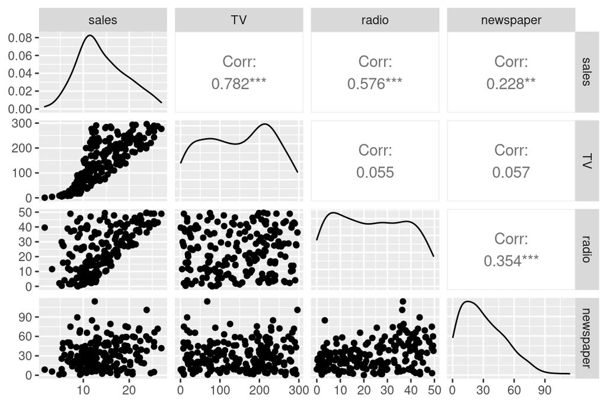

```r
library(GGally)
ggpairs(Advertising[,c(5,2,3,4)])
```

# Categorical Predictors

## Palmer Penguins

```r
library(palmerpenguins)
glimpse(penguins)
```

```
Rows: 344
Columns: 8
$ species           <fct> Adelie, Adelie, Adelie, Adelie, Adelie, Adelie, Adelie, Adelie, Adelie, …
$ island            <fct> Torgersen, Torgersen, Torgersen, Torgersen, Torgersen, Torgersen, Torger…
$ bill_length_mm    <dbl> 39.1, 39.5, 40.3, NA, 36.7, 39.3, 38.9, 39.2, 34.1, 42.0, 37.8, 37.8, 41…
$ bill_depth_mm     <dbl> 18.7, 17.4, 18.0, NA, 19.3, 20.6, 17.8, 19.6, 18.1, 20.2, 17.1, 17.3, 17…
$ flipper_length_mm <int> 181, 186, 195, NA, 193, 190, 181, 195, 193, 190, 186, 180, 182, 191, 198…
$ body_mass_g       <int> 3750, 3800, 3250, NA, 3450, 3650, 3625, 4675, 3475, 4250, 3300, 3700, 32…
$ sex               <fct> male, female, female, NA, female, male, female, male, NA, NA, NA, NA, fe…
$ year              <int> 2007, 2007, 2007, 2007, 2007, 2007, 2007, 2007, 2007, 2007, 2007, 2007, …
```

## Predict body mass

```r
penMod1 <- lm(body_mass_g ~ bill_length_mm + bill_depth_mm + flipper_length_mm, data = penguins)
summary(penMod1)
```

```
Call:
lm(formula = body_mass_g ~ bill_length_mm + bill_depth_mm + flipper_length_mm,
    data = penguins)

Residuals:
     Min       1Q   Median       3Q      Max
-1054.94  -290.33   -21.91   239.04  1276.64

Coefficients:
                   Estimate Std. Error t value Pr(>|t|)
(Intercept)       -6424.765    561.469 -11.443   <2e-16 ***
bill_length_mm        4.162      5.329   0.781    0.435
bill_depth_mm        20.050     13.694   1.464    0.144
flipper_length_mm    50.269      2.477  20.293   <2e-16 ***
---
Signif. codes:  0 '***' 0.001 '**' 0.01 '*' 0.05 '.' 0.1 ' ' 1

Residual standard error: 393.4 on 338 degrees of freedom
  (2 observations deleted due to missingness)
Multiple R-squared:  0.7615,    Adjusted R-squared:  0.7594
F-statistic: 359.7 on 3 and 338 DF,  p-value: < 2.2e-16
```

## Now include species as a predictor

```r
penMod2 <- lm(body_mass_g ~ bill_length_mm + bill_depth_mm + flipper_length_mm + species, data = penguins)
summary(penMod2)
```

```
Call:
lm(formula = body_mass_g ~ bill_length_mm + bill_depth_mm + flipper_length_mm +
    species, data = penguins)

Residuals:
   Min     1Q Median     3Q    Max
-836.0 -200.7  -23.0  202.5 1045.9

Coefficients:
                   Estimate Std. Error t value Pr(>|t|)
(Intercept)       -4327.327    494.866  -8.744  < 2e-16 ***
bill_length_mm       41.468      7.163   5.789 1.62e-08 ***
bill_depth_mm       140.328     18.976   7.395 1.14e-12 ***
flipper_length_mm    20.241      3.105   6.518 2.61e-10 ***
speciesChinstrap   -513.247     82.140  -6.248 1.25e-09 ***
speciesGentoo       934.887    140.778   6.641 1.26e-10 ***
---
Signif. codes:  0 '***' 0.001 '**' 0.01 '*' 0.05 '.' 0.1 ' ' 1

Residual standard error: 315.9 on 336 degrees of freedom
  (2 observations deleted due to missingness)
Multiple R-squared:  0.8471,    Adjusted R-squared:  0.8449
F-statistic: 372.4 on 5 and 336 DF,  p-value: < 2.2e-16
```

## Indicator variables

```
                  Estimate Std. Error t value Pr(>|t|)
(Intercept)        -4330.0     495.00   -8.74 1.09e-16
bill_length_mm        41.5       7.16    5.79 1.62e-08
bill_depth_mm        140.0      19.00    7.40 1.14e-12
flipper_length_mm     20.2       3.11    6.52 2.61e-10
speciesChinstrap    -513.0      82.10   -6.25 1.25e-09
speciesGentoo        935.0     141.00    6.64 1.26e-10
```

- `speciesChinstrap` and `speciesGentoo` are **indicator variables**.
  - Plug in 1 or 0 as appropriate.
- Adelie must be the **baseline** level, because it has no indicator variable.

## Compare the models

```
                  Estimate Std. Error t value Pr(>|t|)
(Intercept)       -6420.00     561.00 -11.400 7.58e-26
bill_length_mm        4.16       5.33   0.781 4.35e-01
bill_depth_mm        20.00      13.70   1.460 1.44e-01
flipper_length_mm    50.30       2.48  20.300 1.93e-60
```

```
                  Estimate Std. Error t value Pr(>|t|)
(Intercept)        -4330.0     495.00   -8.74 1.09e-16
bill_length_mm        41.5       7.16    5.79 1.62e-08
bill_depth_mm        140.0      19.00    7.40 1.14e-12
flipper_length_mm     20.2       3.11    6.52 2.61e-10
speciesChinstrap    -513.0      82.10   -6.25 1.25e-09
speciesGentoo        935.0     141.00    6.64 1.26e-10
```

Discuss: Significance, conditioning, meaning of estimates, etc.